# Unsupervised Learning Winter 2022/2023 - Association rules

Recipes

306068 Dominik Żabiński

# Introduction

Association analysis is associated either with purchasing analysis or purchasing analysis. I decided to check whether it is possible to analyze something yummier - recipes.

Main question is this: are the recipes are as predictable as one might think?

# Data

Data comes from https://www.kaggle.com/datasets/shuyangli94/food-com-recipes-and-user-interactions. As stated:

```
This dataset consists of 180K+ recipes
```

In the first step, process the aforementioned set. It was limited to 20,000. recipes, and the ingredients contained in them have undergone some processing. The code to prepare the collection downloaded from the indicated page is below.

```r
# library(data.table)
# raw <- data.table(read.csv(file = "RAW_recipes.csv", stringsAsFactors = F, nrows = 20000))
# dataRec <- data.table(recipe = raw$ingredients)
# # ingredients are stated as tuples in form: ['itemA, itemB']
# dataRec[, recipe := substr(recipe, 3, nchar(recipe) - 2)]
# # replacing separatro for simpler one
# dataRec[, recipe := gsub(pattern = "', '", replacement = ",", x = recipe, fixed = T)]
# # getting rid of quotation marks and apostrophes
# dataRec[, recipe := gsub(pattern = "'", replacement = "", x = recipe, fixed = T)]
# dataRec[, recipe := gsub(pattern = '"', replacement = "", x = recipe, fixed = T)]
# # there is weird convention for including juice i.e. lemon, juice of - getting rid of it
# dataRec[, recipe := gsub(pattern = ', juice of', replacement = "", x = recipe, fixed = T)]
#
# write.csv(x = dataRec, file = "recipe.csv", row.names = F, quote = FALSE)
```

```r
recipes <- arules::read.transactions(file = "data/recipe.csv", sep = ",", header = T)
```

# Primary analysis

Lets look at basics.

```r
recSumm <- summary(recipes)
recSumm@density
```

```
## [1] 0.00130212
```

The dataset is not very dense - if represented by sparse matrix, only 0.13% of it would be covered.

```r
recSumm@itemSummary
```

```
##    salt  butter   sugar    eggs   onion (Other)
##    7293    4779    4047    3087    2968  155930
```

Most common ingredients are salt, butter, sugar, eggs and onion (unexpectedly, my money’s on flour). We could use `itemFrequencyPlot` function to look at absolute (or relative) frequency of the ingredients.

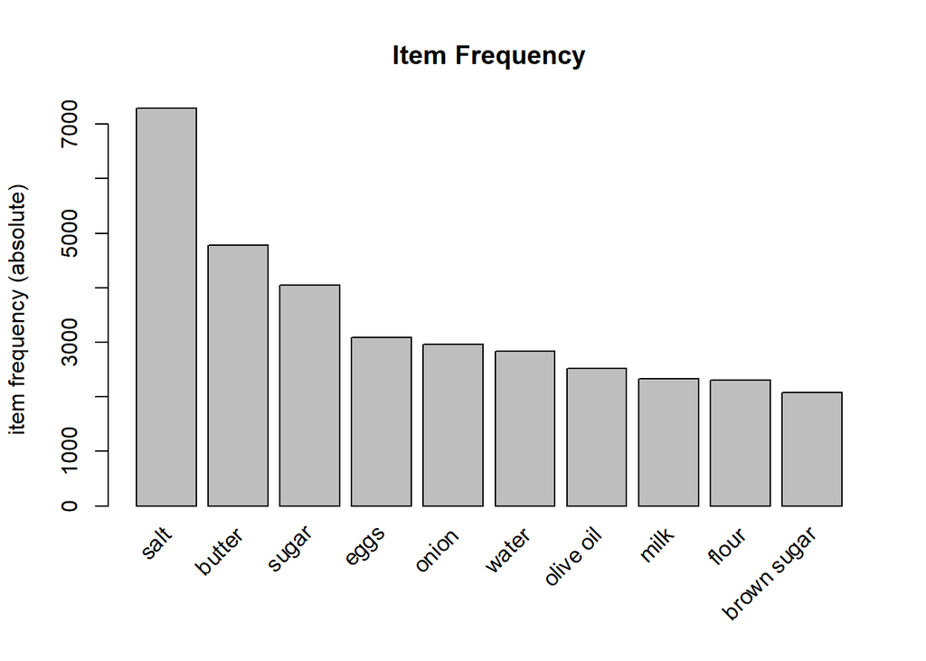

```r
itemFrequencyPlot(recipes, topN=10, type="absolute", main="Item Frequency")
```

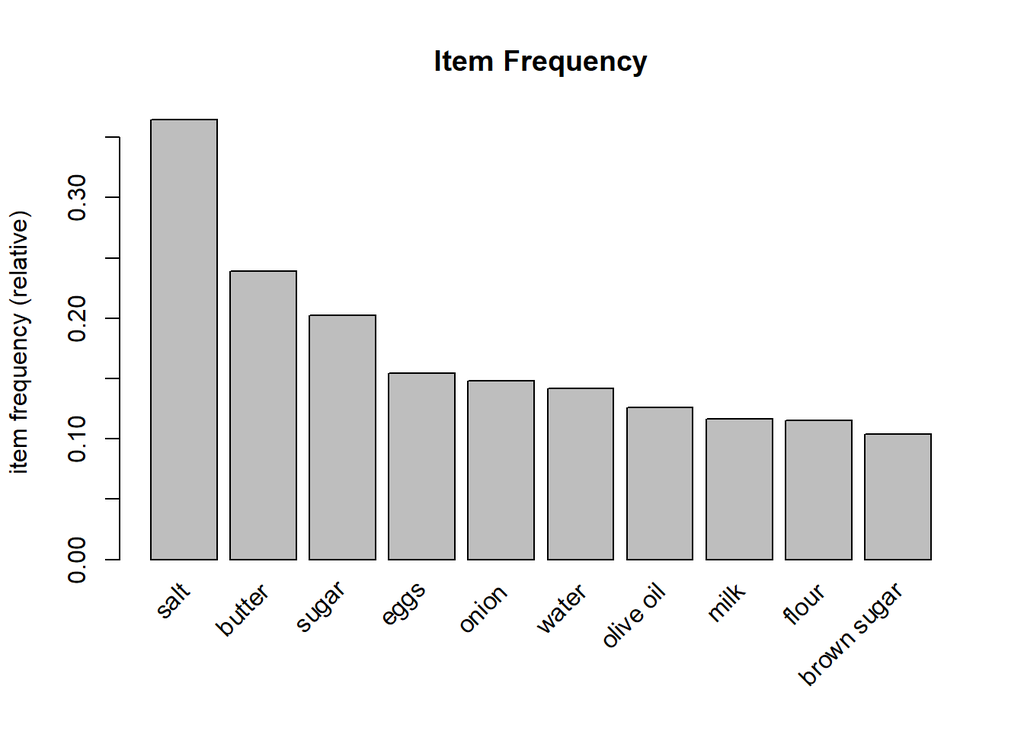

```r
itemFrequencyPlot(recipes, topN=10, type="relative", main="Item Frequency")
```

As we can see in top 10 items are also **water**, **olive oil**, **milk**, **flour** and **brown sugar**

```r
recSumm@lengthSummary
```

```
##    Min. 1st Qu.  Median    Mean 3rd Qu.    Max.
##   1.000   6.000   9.000   8.905  11.000  43.000
```

50% of recipes contains between 6 and 11 ingredients. There are some complex recipes (43 ingredients) and some basic (one ingredient recipe?). Look at the distribution.

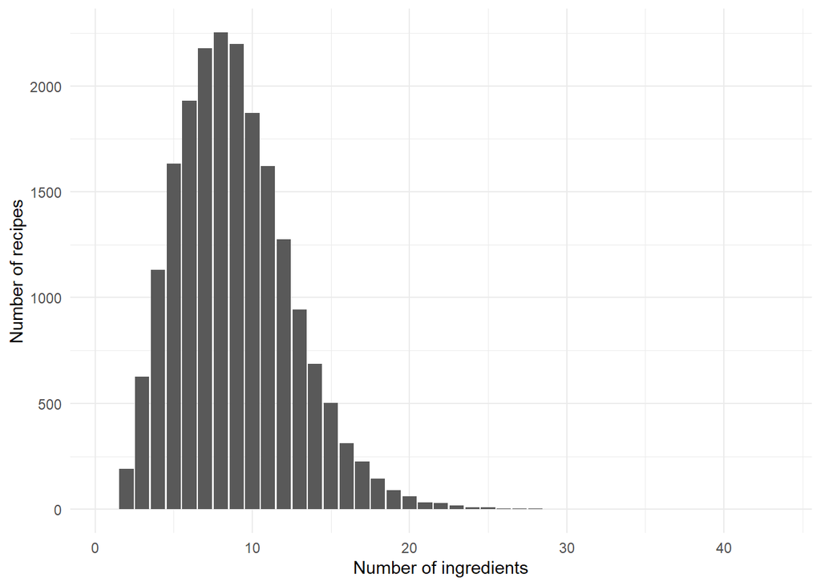

```r
ggplot(data = data.table(m = as.numeric(names(recSumm@lengths)), v = unname(recSumm@lengths))) +
    geom_col(aes(x = m, y  =v.N)) +
    theme_minimal() +
    labs(x = "Number of ingredients", y = "Number of recipes")
```

# Association rules - basics

Using the apriori algorithm I will try to find some association rules. Starting with support at minimum of 6% and confidence of minimum 25%.

```r
recipeRules <- apriori(recipes, parameter = list(support = 0.06, confidence = 0.25, minlen = 2))
```

```
## Apriori
##
## Parameter specification:
##  confidence minval smax arem  aval originalSupport maxtime support minlen
##        0.25    0.1    1 none FALSE            TRUE       5    0.06      2
##  maxlen target  ext
##      10  rules TRUE
##
## Algorithmic control:
##  filter tree heap memopt load sort verbose
##     0.1 TRUE TRUE  FALSE TRUE    2    TRUE
##
## Absolute minimum support count: 1200
##
## set item appearances ...[0 item(s)] done [0.00s].
## set transactions ...[6839 item(s), 20000 transaction(s)] done [0.10s].
## sorting and recoding items ... [21 item(s)] done [0.00s].
## creating transaction tree ... done [0.01s].
## checking subsets of size 1 2 3 done [0.00s].
## writing ... [18 rule(s)] done [0.00s].
## creating S4 object  ... done [0.00s].
```

```r
summary(recipeRules)
```

```
## set of 18 rules
##
## rule length distribution (lhs + rhs):sizes
##  2
## 18
##
##    Min. 1st Qu.  Median    Mean 3rd Qu.    Max.
##       2       2       2       2       2       2
##
## summary of quality measures:
##     support          confidence        coverage            lift
##  Min.   :0.06065   Min.   :0.2538   Min.   :0.08845   Min.   :1.149
##  1st Qu.:0.06266   1st Qu.:0.3046   1st Qu.:0.14349   1st Qu.:1.433
##  Median :0.06830   Median :0.4256   Median :0.17835   Median :1.627
##  Mean   :0.07651   Mean   :0.4458   Mean   :0.19192   Mean   :1.680
##  3rd Qu.:0.08270   3rd Qu.:0.5249   3rd Qu.:0.23895   3rd Qu.:2.001
##  Max.   :0.11055   Max.   :0.7682   Max.   :0.36465   Max.   :2.200
##      count
##  Min.   :1213
##  1st Qu.:1253
##  Median :1366
##  Mean   :1530
##  3rd Qu.:1654
##  Max.   :2211
##
## mining info:
##     data ntransactions support confidence
##  recipes         20000    0.06       0.25
##                                                                                      call
##  apriori(data = recipes, parameter = list(support = 0.06, confidence = 0.25, minlen = 2))
```

Maximum support is 11%, maximum confidence 77% (pretty high).

Inspect rules more carefully. First, look by count.

```r
inspect(sort(recipeRules, by = "count")[1:10])
```

```
##      lhs                rhs      support confidence coverage lift     count
## [1]  {butter}        => {salt}   0.11055 0.4626491  0.23895  1.268748 2211
## [2]  {salt}          => {butter} 0.11055 0.3031674  0.36465  1.268748 2211
## [3]  {sugar}         => {salt}   0.10570 0.5223622  0.20235  1.432503 2114
## [4]  {salt}          => {sugar}  0.10570 0.2898670  0.36465  1.432503 2114
## [5]  {eggs}          => {salt}   0.08610 0.5578231  0.15435  1.529749 1722
## [6]  {flour}         => {salt}   0.07250 0.6285219  0.11535  1.723631 1450
## [7]  {sugar}         => {butter} 0.07215 0.3565604  0.20235  1.492197 1443
## [8]  {butter}        => {sugar}  0.07215 0.3019460  0.23895  1.492197 1443
## [9]  {pepper}        => {salt}   0.06865 0.7632018  0.08995  2.092971 1373
## [10] {baking powder} => {salt}   0.06795 0.7682306  0.08845  2.106762 1359
```

Most common are rules containing **salt** and **sugar**. This is quite obvious since we established that the dataset probably contains mostly recipes for cakes and pastries.

Another way of inspecting a association rules is to look at lift statistic.

```r
inspect(sort(recipeRules, by = "lift")[1:10])
```

```
##      lhs                rhs      support confidence coverage lift     count
## [1]  {flour}         => {butter} 0.06065 0.5257911  0.11535  2.200423 1213
## [2]  {butter}        => {flour}  0.06065 0.2538188  0.23895  2.200423 1213
## [3]  {baking powder} => {salt}   0.06795 0.7682306  0.08845  2.106762 1359
## [4]  {pepper}        => {salt}   0.06865 0.7632018  0.08995  2.092971 1373
## [5]  {eggs}          => {sugar}  0.06250 0.4049239  0.15435  2.001106 1250
## [6]  {sugar}         => {eggs}   0.06250 0.3088708  0.20235  2.001106 1250
## [7]  {eggs}          => {butter} 0.06675 0.4324587  0.15435  1.809829 1335
## [8]  {butter}        => {eggs}   0.06675 0.2793471  0.23895  1.809829 1335
## [9]  {flour}         => {salt}   0.07250 0.6285219  0.11535  1.723631 1450
## [10] {eggs}          => {salt}   0.08610 0.5578231  0.15435  1.529749 1722
```

**Flour** and **butter**, **baking powder** and **salt** - sounds like pastries.

Combination of **pepper** and **salt** is also high in term fo lift. ‘season to taste’ phrase is common in recipes.

Another way of inspecting rules is looking at support level.

```r
inspect(sort(recipeRules, by = "support")[1:10])
```

```
##      lhs                rhs      support confidence coverage lift     count
## [1]  {butter}        => {salt}   0.11055 0.4626491  0.23895  1.268748 2211
## [2]  {salt}          => {butter} 0.11055 0.3031674  0.36465  1.268748 2211
## [3]  {sugar}         => {salt}   0.10570 0.5223622  0.20235  1.432503 2114
## [4]  {salt}          => {sugar}  0.10570 0.2898670  0.36465  1.432503 2114
## [5]  {eggs}          => {salt}   0.08610 0.5578231  0.15435  1.529749 1722
## [6]  {flour}         => {salt}   0.07250 0.6285219  0.11535  1.723631 1450
## [7]  {sugar}         => {butter} 0.07215 0.3565604  0.20235  1.492197 1443
## [8]  {butter}        => {sugar}  0.07215 0.3019460  0.23895  1.492197 1443
## [9]  {pepper}        => {salt}   0.06865 0.7632018  0.08995  2.092971 1373
## [10] {baking powder} => {salt}   0.06795 0.7682306  0.08845  2.106762 1359
```

Most popular combinations in this set of rules are **butter** with **salt** and **salt** with **sugar**.

# Onion as a metaphor for the layering of association rules

Basic analysis of the dataset revealed that we are dealing with cake recipes (or something similar). One of the items stood out - onion. What kind of rules we can make with this ingredient? Since first attempt gave us onyl 18 rules we will lower minimum support from 6% to 1% to create broader set of rules, but with special interest in **onion**. At first, find out what ‘triggers’ including onion into recipe.

```r
onionRules <- apriori(data=recipes, parameter=list(supp = 0.01, conf = 0.005, minlen = 2), appearance=list(default = "lhs", rhs = "onion"), control=list(verbose=F))
onionRules
```

```
## set of 33 rules
```

33 rules including this vegetable. What about those rules, lets look at confidence values:

```r
inspect(head(sort(onionRules, by="confidence", decreasing=TRUE)))
```

```
##     lhs                rhs     support confidence coverage lift     count
## [1] {ground beef}   => {onion} 0.01510 0.5841393  0.02585  3.936248 302
## [2] {celery}        => {onion} 0.01800 0.5013928  0.03590  3.378657 360
## [3] {ketchup}       => {onion} 0.01010 0.4410480  0.02290  2.972022 202
## [4] {carrot}        => {onion} 0.01075 0.4334677  0.02480  2.920942 215
## [5] {chicken broth} => {onion} 0.01150 0.4099822  0.02805  2.762683 230
## [6] {chili powder}  => {onion} 0.01100 0.3935599  0.02795  2.652021 220
```

**Ground beef**, **celery**, **ketchup** - nothing for the sweet tooth. Maybe try differently - what else will people add if already added onion to the recipe?

```r
onionRules2 <- apriori(data = recipes, parameter = list(supp = 0.01, conf = 0.005, minlen = 2), appearance = list(default = "rhs", lhs = "onion"), control = list(verbose = F))
onionRules2
```

```
## set of 27 rules
```

Nearly 30 rules. Again, look at the rules with higher confidence values.

```r
inspect(head(sort(onionRules2, by="confidence", decreasing=TRUE)))
```

```
##     lhs        rhs             support confidence coverage lift      count
## [1] {onion} => {salt}          0.06215 0.4188005  0.1484   1.1485000 1243
## [2] {onion} => {garlic cloves} 0.03135 0.2112534  0.1484   2.2051500  627
## [3] {onion} => {olive oil}     0.03045 0.2051887  0.1484   1.6284816  609
## [4] {onion} => {pepper}        0.03025 0.2038410  0.1484   2.2661586  605
## [5] {onion} => {water}         0.02870 0.1933962  0.1484   1.3633855  574
## [6] {onion} => {butter}        0.02860 0.1927224  0.1484   0.8065385  572
```

**salt**, **garlic cloves**, **olive oil** sound about right but **water** is odd.

# Graphical analysis

To perform graphical analysis first we create more rules by lowering minimal support level (to 0.6%).

```r
recipeRules2 <- apriori(recipes, parameter = list(support = 0.006, confidence = 0.25, minlen = 2))
```

```
## Apriori
##
## Parameter specification:
##  confidence minval smax arem  aval originalSupport maxtime support minlen
##        0.25    0.1    1 none FALSE            TRUE       5   0.006      2
##  maxlen target  ext
##      10  rules TRUE
##
## Algorithmic control:
##  filter tree heap memopt load sort verbose
##     0.1 TRUE TRUE  FALSE TRUE    2    TRUE
##
## Absolute minimum support count: 120
##
## set item appearances ...[0 item(s)] done [0.00s].
## set transactions ...[6839 item(s), 20000 transaction(s)] done [0.10s].
## sorting and recoding items ... [239 item(s)] done [0.00s].
## creating transaction tree ... done [0.01s].
## checking subsets of size 1 2 3 4 5 6 done [0.01s].
## writing ... [2363 rule(s)] done [0.00s].
## creating S4 object  ... done [0.02s].
```

```r
recipeRules2
```

```
## set of 2363 rules
```

That would leave us with 2363 rules. Lets plot 500 of them.

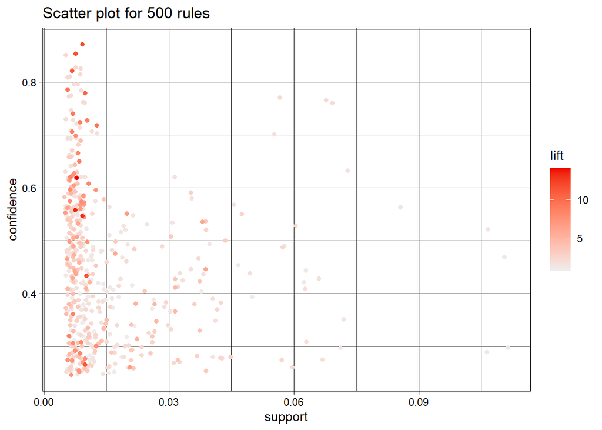

```r
plot(recipeRules2[1:500])
```

There are some rules with confidence (over 80%) but very low support level. Next we look at lift level (with the use of ‘matrix’ method).

```
## Itemsets in Antecedent (LHS)
##   [1] "{sesame oil}"
##   [2] "{brown sugar,nutmeg}"
##   [3] "{nutmeg,sugar}"
##   [4] "{fresh ginger}"
##   [5] "{baking powder,nutmeg}"
##   [6] "{baking soda,cinnamon}"
##   [7] "{flour,nutmeg}"
##   [8] "{cinnamon,flour}"
##   [9] "{cinnamon,salt}"
##  [10] "{onion powder}"
##  [11] "{cinnamon,eggs}"
##  [12] "{eggs,nutmeg}"
##  [13] "{brown sugar,cinnamon}"
##  [14] "{banana,salt}"
```

[output cut: 178 more lines]

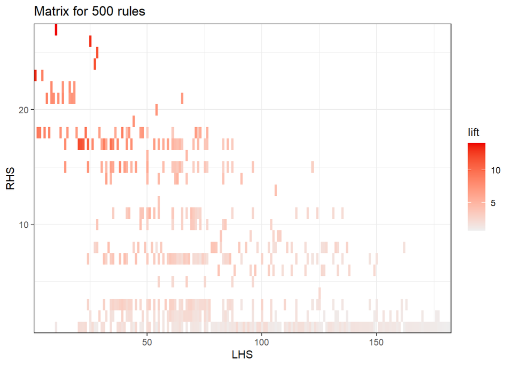

```r
plot(recipeRules2[1:500], method = "matrix", measure = "lift")
```

There are few rules with lift over 10 which is quite promising. Looking at both support and lif (graph below) we can spot some rules with both high confidence and lift.

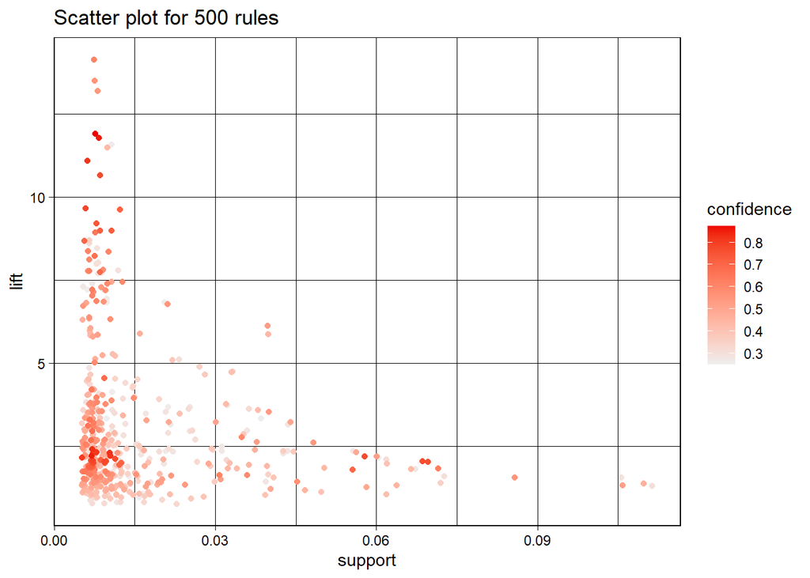

```r
plot(recipeRules2[1:500], measure = c("support", "lift"), shading = "confidence")
```

Looking at grouped graph we can spot several interesting rules:

- **onion powder** and **garlic powder**
- **ground nutmeg** with **ground cinnammon**
- **worcestershire sauce** and **ketchup**

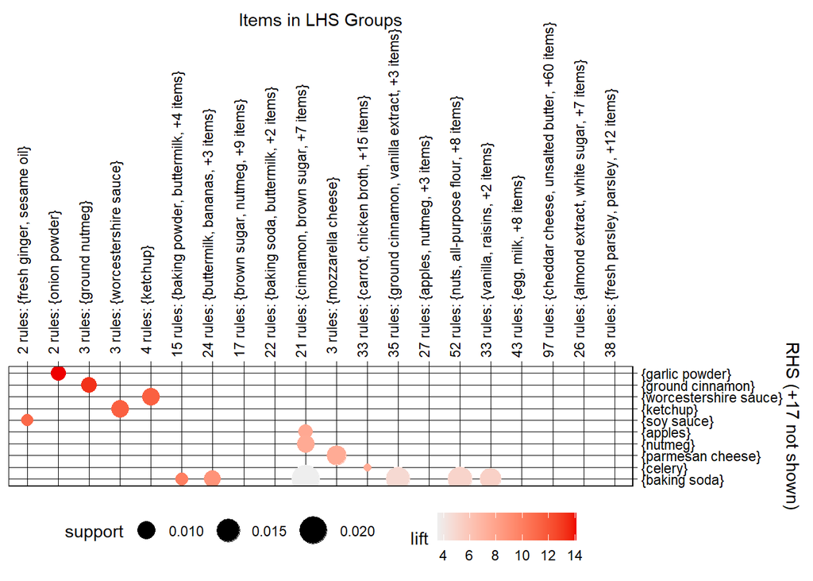

```r
plot(recipeRules2[1:500], method = "grouped")
```

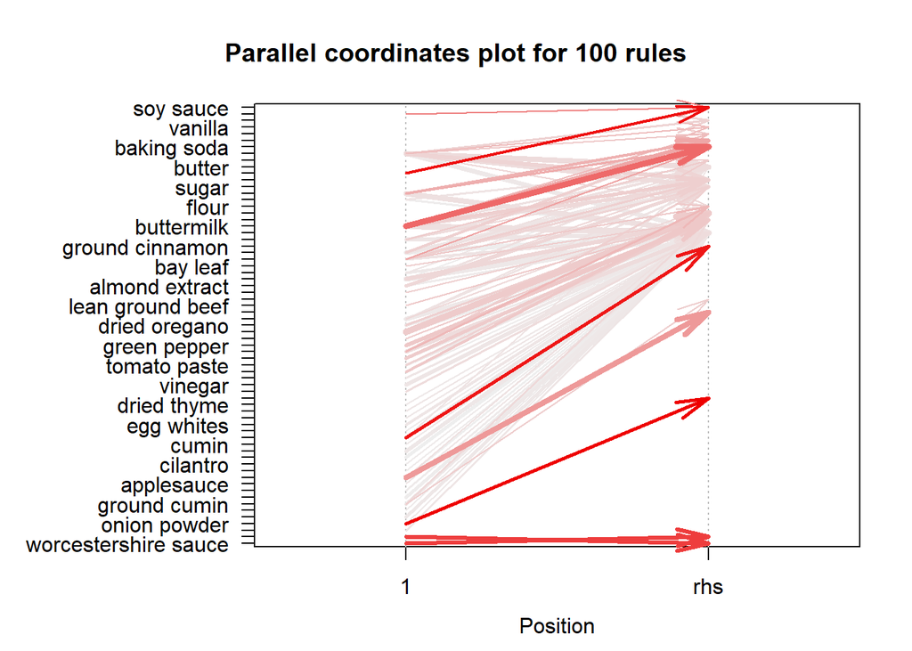

```r
plot(recipeRules2[1:100], method = "paracoord", control = list(reorder = TRUE))
```

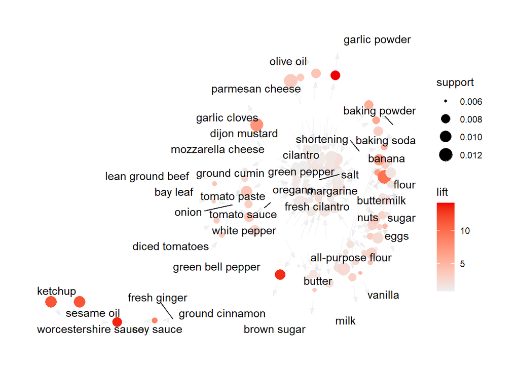

```r
plot(recipeRules2[1:100], method = "graph")
```

# Banana as the example of step-by-step approach

In this part will be presented step-by-step approach to association rules analysis. We will use low support rules to have something to work with.

## What is the cause / consequence of a given igredient?

What leads to putting the banana into the recipe?

```r
rules.banana <- apriori(data=recipes, parameter=list(supp = 0.001,conf = 0.08, minlen = 2), appearance=list(default="lhs", rhs="banana"), control=list(verbose=F))

rules.banana.byconf <- sort(rules.banana, by="confidence", decreasing=TRUE)
inspect(head(rules.banana.byconf))
```

```
##     lhs                              rhs      support confidence coverage
## [1] {ice cubes}                   => {banana} 0.00165 0.3750000  0.0044
## [2] {baking soda, shortening}     => {banana} 0.00105 0.2100000  0.0050
## [3] {eggs, shortening}            => {banana} 0.00100 0.2040816  0.0049
## [4] {baking powder, pecans, salt} => {banana} 0.00105 0.2019231  0.0052
## [5] {ice}                         => {banana} 0.00160 0.2000000  0.0080
## [6] {baking powder, pecans}       => {banana} 0.00115 0.1885246  0.0061
##     lift      count
## [1] 12.500000 33
## [2]  7.000000 21
## [3]  6.802721 20
## [4]  6.730769 21
## [5]  6.666667 32
## [6]  6.284153 23
```

**Pecans**, **salt**, **baking powder** - all are probably part of dish similar to pecan pie. Seeing **ice** is something I could not quite understand.

What is the result of adding a banana?

```r
rules.banana <- apriori(data=recipes, parameter = list(supp = 0.001, conf = 0.08, minlen = 2), appearance=list(default="rhs",lhs="banana"), control=list(verbose=F))

rules.banana.byconf<-sort(rules.banana, by="confidence", decreasing=TRUE)
inspect(head(rules.banana.byconf))
```

```
##     lhs         rhs             support confidence coverage lift      count
## [1] {banana} => {salt}          0.01040 0.3466667  0.03     0.9506833 208
## [2] {banana} => {sugar}         0.00920 0.3066667  0.03     1.5155259 184
## [3] {banana} => {baking powder} 0.00830 0.2766667  0.03     3.1279442 166
## [4] {banana} => {eggs}          0.00755 0.2516667  0.03     1.6304935 151
## [5] {banana} => {baking soda}   0.00745 0.2483333  0.03     3.3786848 149
## [6] {banana} => {butter}        0.00620 0.2066667  0.03     0.8648950 124
```

Apparently adding a *banana* to the recipe results in adding *salt*, *sugar*, *baking powder/soda*, *eggs* or *butter* (at least that are the ingredients we are most confident about)

## Sets

Finding out closed (frequent) sets is useful part of association rules analysis.

```r
trans1.closed<-apriori(recipes, parameter=list(target="closed frequent itemsets", support=0.025, minlen = 2))
```

```
## Apriori
##
## Parameter specification:
##  confidence minval smax arem  aval originalSupport maxtime support minlen
##          NA    0.1    1 none FALSE            TRUE       5   0.025      2
##  maxlen                   target  ext
##      10 closed frequent itemsets TRUE
##
## Algorithmic control:
##  filter tree heap memopt load sort verbose
##     0.1 TRUE TRUE  FALSE TRUE    2    TRUE
##
## Absolute minimum support count: 500
##
## set item appearances ...[0 item(s)] done [0.00s].
## set transactions ...[6839 item(s), 20000 transaction(s)] done [0.11s].
## sorting and recoding items ... [61 item(s)] done [0.00s].
## creating transaction tree ... done [0.00s].
## checking subsets of size 1 2 3 4 done [0.00s].
## filtering closed item sets ... done [0.00s].
## sorting transactions ... done [0.00s].
## writing ... [90 set(s)] done [0.00s].
## creating S4 object  ... done [0.00s].
```

```r
inspect(trans1.closed)
```

```
##      items                                    support count
## [1]  {black pepper, salt}                     0.03145  629
## [2]  {eggs, vanilla}                          0.03060  612
## [3]  {sugar, vanilla}                         0.03515  703
## [4]  {butter, vanilla}                        0.02930  586
## [5]  {salt, vanilla}                          0.03500  700
## [6]  {salt, vegetable oil}                    0.03125  625
## [7]  {lemon juice, salt}                      0.02705  541
## [8]  {garlic, salt}                           0.02575  515
## [9]  {baking powder, egg}                     0.02530  506
## [10] {egg, sugar}                             0.02960  592
## [11] {butter, egg}                            0.02950  590
## [12] {egg, salt}                              0.04580  916
## [13] {cinnamon, flour}                        0.02655  531
## [14] {cinnamon, eggs}                         0.02585  517
```

[output cut: 76 more lines]

```r
is.closed(trans1.closed)
```

```
##                    {black pepper,salt}                         {eggs,vanilla}
##                                   TRUE                                   TRUE
##                        {sugar,vanilla}                       {butter,vanilla}
##                                   TRUE                                   TRUE
##                         {salt,vanilla}                   {salt,vegetable oil}
##                                   TRUE                                   TRUE
##                     {lemon juice,salt}                          {garlic,salt}
##                                   TRUE                                   TRUE
##                    {baking powder,egg}                            {egg,sugar}
##                                   TRUE                                   TRUE
##                           {butter,egg}                             {egg,salt}
##                                   TRUE                                   TRUE
##                       {cinnamon,flour}                        {cinnamon,eggs}
##                                   TRUE                                   TRUE
##                       {cinnamon,sugar}                      {butter,cinnamon}
##                                   TRUE                                   TRUE
##                        {cinnamon,salt}        {all-purpose flour,baking soda}
##                                   TRUE                                   TRUE
##            {baking powder,baking soda}                    {baking soda,flour}
##                                   TRUE                                   TRUE
##                     {baking soda,eggs}                    {baking soda,sugar}
##                                   TRUE                                   TRUE
##                   {baking soda,butter}                     {baking soda,salt}
##                                   TRUE                                   TRUE
##      {all-purpose flour,baking powder}               {all-purpose flour,eggs}
##                                   TRUE                                   TRUE
##              {all-purpose flour,sugar}             {all-purpose flour,butter}
##                                   TRUE                                   TRUE
##               {all-purpose flour,salt}                         {onion,pepper}
##                                   TRUE                                   TRUE
##                          {pepper,salt}                   {baking powder,milk}
##                                   TRUE                                   TRUE
##                  {baking powder,flour}                   {baking powder,eggs}
##                                   TRUE                                   TRUE
##                  {baking powder,sugar}                 {baking powder,butter}
##                                   TRUE                                   TRUE
##                   {baking powder,salt}                   {brown sugar,butter}
##                                   TRUE                                   TRUE
##                     {brown sugar,salt}              {garlic cloves,olive oil}
##                                   TRUE                                   TRUE
```

[output cut: 35 more lines]

```
##                                   TRUE                                   TRUE
##             {baking powder,salt,sugar}            {baking powder,butter,salt}
##                                   TRUE                                   TRUE
##                       {eggs,milk,salt}                      {milk,salt,sugar}
##                                   TRUE                                   TRUE
##                     {butter,milk,salt}                     {eggs,flour,sugar}
##                                   TRUE                                   TRUE
##                      {eggs,flour,salt}                   {butter,flour,sugar}
##                                   TRUE                                   TRUE
##                     {flour,salt,sugar}                    {butter,flour,salt}
##                                   TRUE                                   TRUE
##                    {butter,eggs,sugar}                      {eggs,salt,sugar}
##                                   TRUE                                   TRUE
##                     {butter,eggs,salt}                    {butter,salt,sugar}
##                                   TRUE                                   TRUE
```

```r
freq.closed<-eclat(recipes, parameter=list(supp=0.15, maxlen=15, target="closed frequent itemsets"))
```

```
## Eclat
##
## parameter specification:
##  tidLists support minlen maxlen                   target  ext
##     FALSE    0.15      1     15 closed frequent itemsets TRUE
##
## algorithmic control:
##  sparse sort verbose
##       7   -2    TRUE
##
## Absolute minimum support count: 3000
##
## create itemset ...
## set transactions ...[6839 item(s), 20000 transaction(s)] done [0.09s].
## sorting and recoding items ... [4 item(s)] done [0.00s].
## creating bit matrix ... [4 row(s), 20000 column(s)] done [0.00s].
## writing  ... [4 set(s)] done [0.00s].
## Creating S4 object  ... done [0.00s].
```

```r
inspect(freq.closed)
```

```
##     items    support count
## [1] {salt}   0.36465 7293
## [2] {butter} 0.23895 4779
## [3] {sugar}  0.20235 4047
## [4] {eggs}   0.15435 3087
```

```r
is.closed(freq.closed)
```

```
##   {salt} {butter}  {sugar}   {eggs}
##     TRUE     TRUE     TRUE     TRUE
```

```r
freq.max<-eclat(recipes, parameter=list(supp=0.15, maxlen=15, target="maximally frequent itemsets"))
```

```
## Eclat
##
## parameter specification:
##  tidLists support minlen maxlen                      target  ext
##     FALSE    0.15      1     15 maximally frequent itemsets TRUE
##
## algorithmic control:
##  sparse sort verbose
##       7   -2    TRUE
##
## Absolute minimum support count: 3000
##
## create itemset ...
## set transactions ...[6839 item(s), 20000 transaction(s)] done [0.08s].
## sorting and recoding items ... [4 item(s)] done [0.00s].
## creating bit matrix ... [4 row(s), 20000 column(s)] done [0.00s].
## writing  ... [4 set(s)] done [0.00s].
## Creating S4 object  ... done [0.00s].
```

```r
inspect(freq.max)
```

```
##     items    support count
## [1] {salt}   0.36465 7293
## [2] {butter} 0.23895 4779
## [3] {sugar}  0.20235 4047
## [4] {eggs}   0.15435 3087
```

## Are the rules significant?

Significance of a rule might tell us whether to use this rules in further analysis.

```r
is.significant(rules.banana, recipes)
```

```
##  [1]  TRUE  TRUE  TRUE  TRUE  TRUE  TRUE  TRUE  TRUE  TRUE FALSE  TRUE FALSE
## [13] FALSE  TRUE  TRUE FALSE FALSE
```

Most of the rules about **banana** are significant.

## Are those sets maximal?

```r
is.maximal(rules.banana)
```

```
##           {banana,walnuts}             {banana,honey}
##                       TRUE                       TRUE
##   {banana,vanilla extract}           {banana,vanilla}
##                       TRUE                       TRUE
##               {banana,egg}          {banana,cinnamon}
##                       TRUE                       TRUE
##       {baking soda,banana} {all-purpose flour,banana}
##                       TRUE                       TRUE
##     {baking powder,banana}       {banana,brown sugar}
##                       TRUE                       TRUE
##              {banana,milk}             {banana,flour}
##                       TRUE                       TRUE
##             {banana,water}              {banana,eggs}
##                       TRUE                       TRUE
##             {banana,sugar}            {banana,butter}
##                       TRUE                       TRUE
##              {banana,salt}
##                       TRUE
```

```r
inspect(rules.banana[is.maximal(rules.banana)==TRUE])
```

```
##      lhs         rhs                 support confidence coverage lift
## [1]  {banana} => {walnuts}           0.00250 0.08333333 0.03     2.4437928
## [2]  {banana} => {honey}             0.00300 0.10000000 0.03     2.0597322
## [3]  {banana} => {vanilla extract}   0.00420 0.14000000 0.03     3.1460674
## [4]  {banana} => {vanilla}           0.00505 0.16833333 0.03     2.8149387
## [5]  {banana} => {egg}               0.00390 0.13000000 0.03     1.6189290
## [6]  {banana} => {cinnamon}          0.00455 0.15166667 0.03     1.8770627
## [7]  {banana} => {baking soda}       0.00745 0.24833333 0.03     3.3786848
## [8]  {banana} => {all-purpose flour} 0.00505 0.16833333 0.03     2.1457404
## [9]  {banana} => {baking powder}     0.00830 0.27666667 0.03     3.1279442
## [10] {banana} => {brown sugar}       0.00390 0.13000000 0.03     1.2506013
## [11] {banana} => {milk}              0.00610 0.20333333 0.03     1.7408676
## [12] {banana} => {flour}             0.00430 0.14333333 0.03     1.2425950
## [13] {banana} => {water}             0.00295 0.09833333 0.03     0.6932205
## [14] {banana} => {eggs}              0.00755 0.25166667 0.03     1.6304935
```

[output cut: 21 more lines]

All of the sets are maximal.

## Are those rules redundant?

The rule is redundant if there is a more general one with the same or higher confidence value.

```r
is.redundant(rules.banana)
```

```
##  [1] FALSE FALSE FALSE FALSE FALSE FALSE FALSE FALSE FALSE FALSE FALSE FALSE
## [13] FALSE FALSE FALSE FALSE FALSE
```

None of the rules is redundant.

# Similarity and dissimilarity measures

I will use Jaccard Index to analyse dissimilarity (only ingredients that appeared in no less than 5% of recipes).

```r
trans.sel<-recipes[,itemFrequency(recipes)>0.05]
d.jac.i<-dissimilarity(trans.sel, which="items")
round(d.jac.i,2)
```

```
##                 all-purpose flour bacon baking powder baking soda black pepper
## bacon                        0.98
## baking powder                0.76  0.99
## baking soda                  0.78  1.00          0.68
## black pepper                 0.98  0.96          1.00        1.00
## brown sugar                  0.91  0.97          0.89        0.86         0.98
## butter                       0.87  0.96          0.87        0.88         0.97
## cinnamon                     0.92  1.00          0.85        0.84         0.99
## egg                          0.87  0.98          0.82        0.87         0.98
## eggs                         0.85  0.95          0.78        0.79         0.98
## flour                        0.99  0.98          0.78        0.80         0.98
## garlic                       0.99  0.97          1.00        1.00         0.93
## garlic cloves                0.99  0.97          1.00        1.00         0.93
## lemon juice                  0.97  0.98          0.97        0.98         0.97
## milk                         0.89  0.95          0.85        0.94         0.98
## olive oil                    0.98  0.98          0.99        1.00         0.93
## onion                        0.98  0.92          0.99        1.00         0.94
## parmesan cheese              0.98  0.96          1.00        1.00         0.95
## pepper                       0.98  0.93          1.00        1.00         1.00
## salt                         0.86  0.95          0.82        0.85         0.92
## salt and pepper              0.99  0.95          1.00        1.00         1.00
## sugar                        0.87  0.98          0.80        0.84         0.98
## vanilla                      0.91  1.00          0.84        0.79         1.00
## vegetable oil                0.92  0.98          0.91        0.91         0.97
## water                        0.95  0.97          0.96        0.96         0.96
##                 brown sugar butter cinnamon  egg eggs flour garlic
## bacon
## baking powder
## baking soda
## black pepper
## brown sugar
## butter                 0.86
## cinnamon               0.85   0.88
## egg                    0.91   0.90     0.91
## eggs                   0.90   0.80     0.88 0.99
## flour                  0.88   0.79     0.84 0.87 0.81
## garlic                 0.98   0.96     0.99 0.99 0.99  0.98
## garlic cloves          0.97   0.96     0.99 0.98 0.98  0.98   1.00
## lemon juice            0.95   0.94     0.95 0.97 0.97  0.97   0.96
## milk                   0.93   0.83     0.92 0.88 0.81  0.84   0.99
```

[output cut: 45 more lines]

```
## flour
## garlic
## garlic cloves
## lemon juice
## milk
## olive oil
## onion
## parmesan cheese
## pepper
## salt              0.82
## salt and pepper   0.99 0.99
## sugar             0.97 0.77            0.99
## vanilla           1.00 0.91            1.00  0.85
## vegetable oil     0.96 0.92            0.98  0.93    0.96
## water             0.94 0.86            0.97  0.87    0.97          0.94
```

For example, **bacon** and **all-purpose flour** are very different - they do not overlap in 98% of the recipes.

Another approach is to show this results using dendrogram. One can see how closely th **garlic cloves** are with **olive oil** and how dissimilar are from **baking-soda**, **baking-powder** and **all-purpose flour** (witch makes sense, unless one is making pizza).

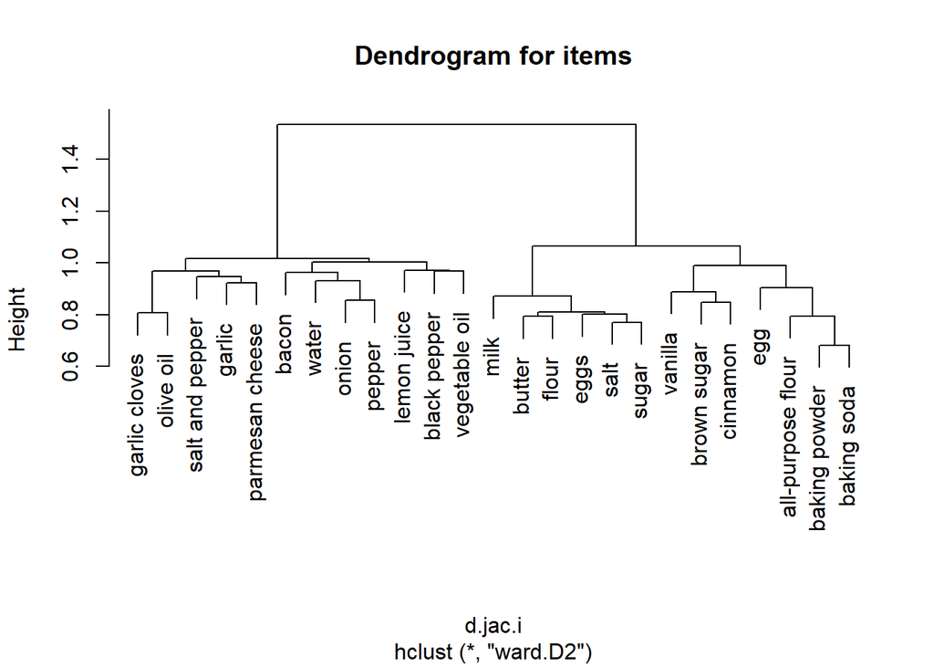

```r
plot(hclust(d = d.jac.i, method = "ward.D2"), main = "Dendrogram for items")
```

# Summary

Association rules analysis is useful not only at finding out what customers will buy next but also at analysing ordinary stuff like recipes. The above analysis could benefit from thorough cleaning up dataset i.e. replacing specific ingredients with more general names.

There were some interesting observations i.e.:

Going back to the main question: there were couple things (like **banana** and **ice cubes**) that were a big surprise but in the end the results were quite predictable.